# Part II - Investigate Ford GoBike System Dataset

## Investigation Overview

> I'm most interested in figuring out what features are best for predicting the duration of bike rides in the dataset.

## Dataset Overview

> This data set includes information about individual rides made in a bike-sharing system covering the greater San Francisco Bay area.There are 65,819 individual rides in the dataset with 16 features. The outliers and data sets containing null values were removed during the data cleaning step.

### Distribution of Duration in Minutes

The duration has a normal distribution which peak between minutes 8 and 10.

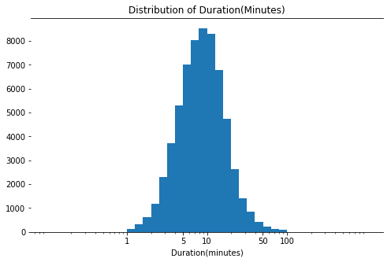

## Age distribution of Riders

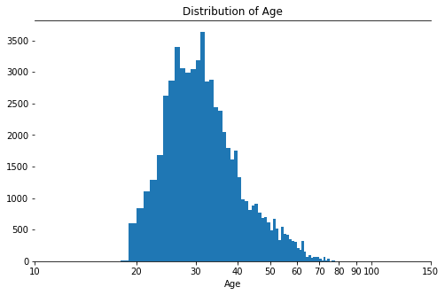

### Distribution of Gender and User Type

> 90.3% of the overall riders were from subscribers while males make up for 74.4% of the overall rides which is a pretty high number.

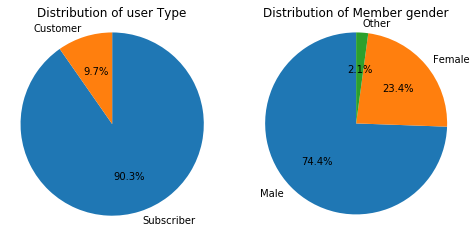

## Relationship between duration and age

There is an inverse relationship between duration of a ride and age of a riser, i.e the younger a rider is the longer the trip. Older riders tend to have shorter trips.

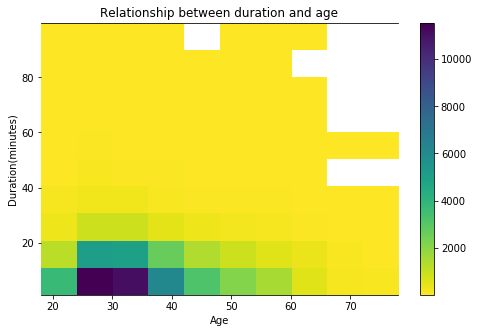

### Bivariate Exploration of categorical variables

### Relationship between duration and gender

> Male riders make shorter trips as compared to females and other genders.

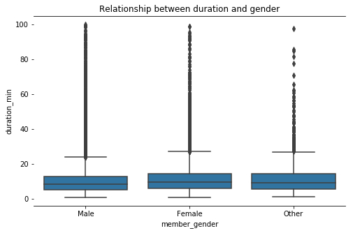

### Relationship between duration and user type

Customers make longer trips than subsriber.

[figure not shown]

## Relationship between Duration, age and gender.

Riders from the age of 70-80 take shorter trips across all genders and they are fewer. It can also be noted that there is a high concentration of riders for other genders around the ages of 56-57.

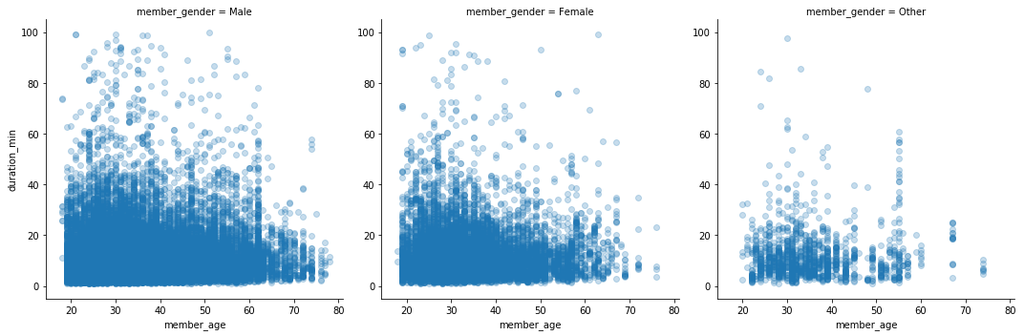

## Conclusions

> From the above analysis it can be clearly observed that Gender and age determine the duration of a trip of a rider.